# individual1.Rmd

Caleb Purcell

11/9/2020

## Loading Packages

```r
library(ggplot2)
library(tidyverse)
library(readxl)
library(lubridate)
library(dplyr)
library(plotly)
library(ggrepel)
library(maps)
library(mapproj)
```

## Importing Datasets

```r
acc <- read.csv("https://raw.githubusercontent.com/xdaiISU/ds202materials/master/hwlabs/fars2017/accident.csv", stringsAsFactors = FALSE)

person <- read.csv("https://raw.githubusercontent.com/xdaiISU/ds202materials/master/hwlabs/fars2017/person.csv", stringsAsFactors = FALSE)
```

## 1. Are there some days of the week where more accidents happen than the others (see FARS manual, use variable DAY_WEEK)?

```r
acc$DAY_WEEK = as.factor(acc$DAY_WEEK)
levels(acc$DAY_WEEK) =  c("Sunday", "Monday", "Tuesday", "Wednesday", "Thursday", "Friday", "Saturday")

acc %>%
  group_by(DAY_WEEK) %>%
  summarise(total_acc = n()) %>%
  arrange(desc(total_acc))
```

```
## # A tibble: 7 x 2
##   DAY_WEEK  total_acc
##   <fct>         <int>
## 1 Saturday       5873
## 2 Sunday         5360
## 3 Friday         5358
## 4 Thursday       4621
## 5 Monday         4374
## 6 Tuesday        4347
## 7 Wednesday      4314
```

```
There are 3 days that stand out when looking at this table, and they all happen to be on or near the weekend.  Sunday and Friday have more total accidents compared to the rest of the week, but Saturday has the most with 5873 accidents.
```

## 2. Create a data frame containing the persons who are fatally hurt in the accidents (look up variable INJ_SEV)

```r
fatal_hurt <- person %>%
  filter(INJ_SEV == 4)

head(fatal_hurt)
```

```
##   STATE ST_CASE VE_FORMS VEH_NO PER_NO STR_VEH COUNTY DAY MONTH HOUR MINUTE
## 1     1   10001        1      1      1       0     73  19     2   23     35
## 2     1   10002        1      1      1       0     89  14     2   14     59
## 3     1   10003        3      2      1       0    101  31     1   20     31
## 4     1   10004        1      1      1       0     73   1     1   16     55
## 5     1   10005        1      1      1       0     13   1     1   20      0
## 6     1   10006        2      1      1       0     49   6     1   18     40
##   RUR_URB FUNC_SYS HARM_EV MAN_COLL SCH_BUS MAKE MAK_MOD BODY_TYP MOD_YEAR
## 1       2        1      38        0       0   20   20421       15     2004
## 2       2        1       1        0       0   37   37402       14     2005
## 3       2        1      12        1       0    2    2404       14     2003
## 4       2        4      30        0       0   30   30046        4     2014
## 5       1        1      35        0       0   12   12471       34     2010
## 6       1        1      34        0       0   49   49032        4     1997
##   TOW_VEH SPEC_USE EMER_USE ROLLOVER IMPACT1 FIRE_EXP AGE SEX PER_TYP INJ_SEV
```

[output cut: 41 more lines]

## 3. Create a data frame containing the most dangerous vehicle make in each state. The number of persons fatally hit in the vehicle make is used to assess the (non-)safety of a make. Make sure to handle the missing values appropriately. (look up variable MAKE)

```r
dangerous_cars <- person %>%
  filter(INJ_SEV == 4) %>%
  filter(is.na(MAKE) == FALSE) %>%
  group_by(STATE, MAKE) %>%
  summarise(total_fatal_acc = n()) %>%
  group_by(STATE) %>%
  filter(total_fatal_acc == max(total_fatal_acc))

head(dangerous_cars)
```

```
## # A tibble: 6 x 3
## # Groups:   STATE [6]
##   STATE  MAKE total_fatal_acc
##   <int> <int>           <int>
## 1     1    12             138
## 2     2    12               9
## 3     4    20              88
## 4     5    20              88
## 5     6    49             351
## 6     8    12              63
```

```r
# Vehicle Make Codes: "12" = Ford, "20" = Chevrolet, "37" = Honda, "49" = Toyota
```

## 4. Create a map, and label each state with the most dangerous vehicle. Discuss the definition of the most dangerous vehicle, and what you find from the map. (Hint: Read the description for the STATE and COUNTY columns in the FARS manual. The state & county codes are Geographic Locator Codes (GLCs) from the General Services Administration’s (GSA) publication. Use readxl::read_xlsx to read in the GLCs.)

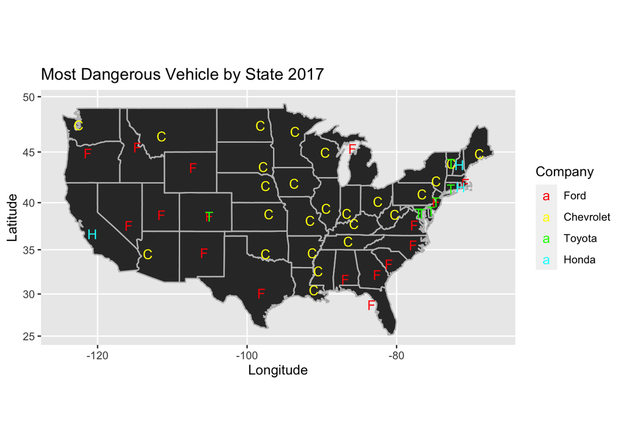

[output not shown]

```r
# Loading data
glc <- read_xlsx('FRPP_GLC_-_United_StatesSep292020.xlsx')
states <- map_data('state')

# Cleaning data
glc$`State Code` = as.numeric(glc$`State Code`)
dangerous_cars$MAKE = as.factor(dangerous_cars$MAKE)

# Joining Data Frames
text <- dangerous_cars %>%
  left_join(glc %>%
              select(c('State Name', 'State Code')),
            by = c('STATE' = 'State Code')) %>%
  unique() %>%
  mutate(`State Name` = tolower(`State Name`)) %>%
  left_join(states %>%
              select(long, lat, region),
            by = c('State Name' = 'region'))

# Setting Location & Removing Alaska and Hawaii
location <- text %>%
  group_by(STATE, MAKE) %>%
  summarise(long = mean(long, na.rm = TRUE), lat = mean(lat, na.rm = TRUE)) %>%
  filter(!STATE %in% c(2, 15))

# Renaming Levels of MAKE
levels(location$MAKE) =  c("F", "C", "T", "H")

# Visualization
ggplot(states, aes(x = long, y = lat)) +
  geom_polygon(aes(group = group)) +
  geom_path(aes(group = group), color = 'grey') +
  geom_text(data = location, aes(x = long, y = lat, label = MAKE, color = MAKE)) +
  coord_map() +
  xlab('Longitude') +
  ylab('Latitude') +
  labs(color = 'Company') +
  ggtitle('Most Dangerous Vehicle by State 2017') +
  scale_color_manual(values = c("#FF0000", "#FFFF00", "#00FF00", "#00FFFF"), labels = c("Ford", "Chevrolet", "Toyota", "Honda"))
```

## 5. Join the accident and person table (work out which variable(s) to use)

```r
acc_person = acc %>%
  select(c(STATE, DAY_WEEK, HOUR)) %>%
  inner_join(person %>%
               select(c(STATE, SEX, AGE, INJ_SEV)),
             by = 'STATE')

head(acc_person)
```

```
##   STATE DAY_WEEK HOUR SEX AGE INJ_SEV
## 1     1   Sunday   23   1  42       4
## 2     1   Sunday   23   1  43       4
## 3     1   Sunday   23   1  63       0
## 4     1   Sunday   23   1  47       4
## 5     1   Sunday   23   1  64       0
## 6     1   Sunday   23   1  18       4
```

## 6. Tally the number of accidents by day of the week (DAY_WEEK), hour of the day (HOUR) and gender (SEX). Visualize the results.

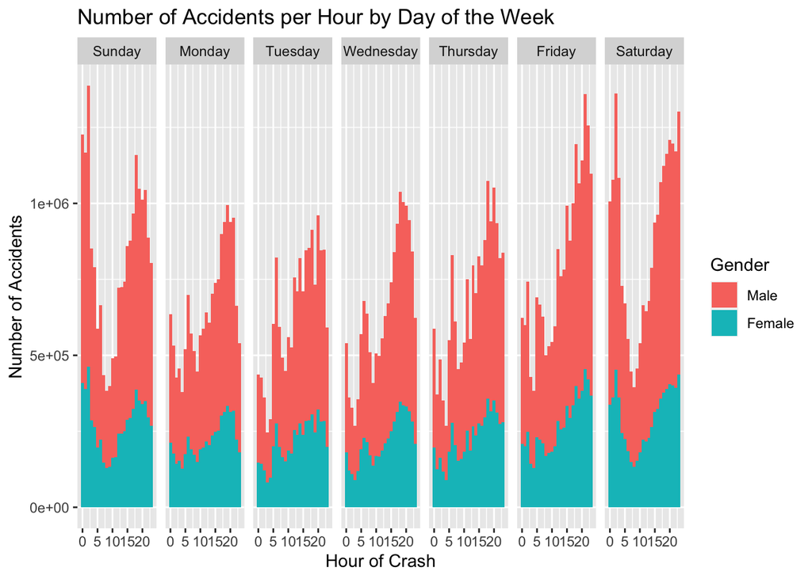

```
This visualization shows how the number of accidents increases towards the end of the day for all days of the week.  Accidents are most common during the late evening and early morning hours.
```

```r
# Tallying Number of Accidents
acc_person_dow <- acc_person %>%
  group_by(DAY_WEEK, HOUR, SEX) %>%
  summarise(total_acc = n()) %>%
  arrange(desc(total_acc))

# Cleaning Data
acc_person_dow <- acc_person_dow %>%
  filter(SEX %in% c(1, 2),
         HOUR != 99)
acc_person_dow$SEX = as.factor(acc_person_dow$SEX)
levels(acc_person_dow$SEX) =  c("Male", "Female")

# Visualization
acc_person_dow %>%
  ggplot(aes(x = HOUR, weight = total_acc, fill = SEX)) +
  geom_histogram(bins = 24) +
  facet_grid(~DAY_WEEK) +
  ggtitle('Number of Accidents per Hour by Day of the Week') +
  xlab('Hour of Crash') +
  ylab('Number of Accidents') +
  labs(fill = 'Gender')
```

## 7. Now plot a choropleth map of the number of deaths on a county level.

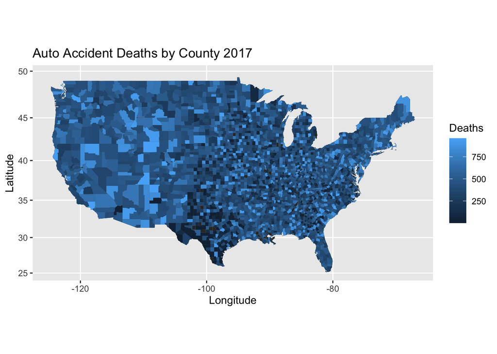

```
From ths map, we can see there are less auto deaths in rural counties.  This can be seen in Southern Texas as well as parts of the upper Midwest.
```

```r
# Selecting/Cleaning Data
counties <- map_data("county") %>%
  rename("County Name" = subregion)
county_codes <- glc %>%
  select(c('County Name', 'County Code'))
county_codes$"County Code" <- as.numeric(as.character(county_codes$"County Code"))

# Grouping by County and Joining Data Frames
county_deaths1 <- acc %>%
  group_by(COUNTY) %>%
  summarise('Deaths' = sum(FATALS), .groups = 'drop') %>%
  rename('County Code' = COUNTY)

county_deaths2 <- county_deaths1 %>%
  inner_join(county_codes, by = 'County Code') %>%
  mutate(`County Name` = tolower(`County Name`)) %>%
  distinct() %>%
  inner_join(counties, by ='County Name')

# Visualization
ggplot(counties, aes(x = long, y = lat)) + geom_polygon(aes(group = group)) + geom_polygon(data = county_deaths2, aes(x = long, y = lat, group = group, fill = `Deaths`))+ coord_map() + ggtitle('Auto Accident Deaths by County 2017') + labs(x="Longitude", y="Latitude")
```

## 8. Is summer or winter more dangerous? Does this depend on states? Explore and explain.

```r
# Filtering by Season
summer <- acc %>%
  filter(MONTH == 6 | MONTH == 7 | MONTH == 8)
winter <- acc %>%
  filter(MONTH == 1 | MONTH == 2 | MONTH == 12)

# Grouping by State
summer %>%
  group_by(STATE) %>%
  summarise("Summer Total" = n(), .groups = 'drop')%>%
  head("Summer Total")
```

```
## # A tibble: 51 x 2
##    STATE `Summer Total`
##    <int>          <int>
##  1     1            221
##  2     2             23
##  3     4            226
##  4     5            127
##  5     6            871
##  6     8            191
##  7     9             62
##  8    10             28
##  9    11             10
## 10    12            675
## # … with 41 more rows
```

```r
winter %>%
  group_by(STATE) %>%
  summarise("Winter Total" = n(), .groups = 'drop')%>%
  head("Winter Total")
```

```
## # A tibble: 51 x 2
##    STATE `Winter Total`
##    <int>          <int>
##  1     1            199
##  2     2             21
##  3     4            223
##  4     5            104
##  5     6            785
##  6     8            117
##  7     9             60
##  8    10             25
##  9    11              7
## 10    12            768
## # … with 41 more rows
```

```r
# Total Accidents by Season
summer %>%
  tally() %>%
  rename("Summer Total Accidents" = n)
```

```
##   Summer Total Accidents
## 1                   9205
```

```r
winter %>%
  tally() %>%
  rename("Winter Total Accidents" = n)
```

```
##   Winter Total Accidents
## 1                   7733
```

[output not shown]